# Semantic Textual Similarity (STS) Interim Submission

**Team Members**: Aditya Raghuvanshi, Satya Swaroop Gudipudi, Harinie Sivaramasethu  
**Team Number:** 4

### Description:

As part of the project, we have explored various approaches and in this report we walkthrough regarding datasets we used, our approaches, our findings and next steps. We will also recap our committed timelines as reported in project outline.

### Approach:

We have performed exploratory data anlaysis to identify any patterns and applied tokenization by ensuring we filter noise in the data and finally we applied embeddings to convert text to meaningful representation.And then we applied normalized cosine similarity to derive the similarity scores. The predicted scores are evaluated with pearson correlation against actual scores.

#### Exploratory Data Analysis(EDA):

Dataset downloaded from hugging face repo originally extracted from STS Benchmark and the data available at this location https://github.com/PhilipMay/stsb-multi-mt

Training Data: 5749

Validation Data: 1500

Test Data: 1379

Total vocab size: 8306

#### Tokenization:

Applied following preprocessing steps as part of tokenization:

Remove punctuation

Replace numbers with num tag

Lower case

Applied Lemmatization

Applied Stemming

Unknown treatment by replacing all words with frequency count 0 and 1 with unk tag

After applying the above preprocessing steps the length of the sentences greatly reduced.  
Maximum length of sentence in training data before preprocessing : 360  
Maximum length of sentence in training data after preprocessing : 40

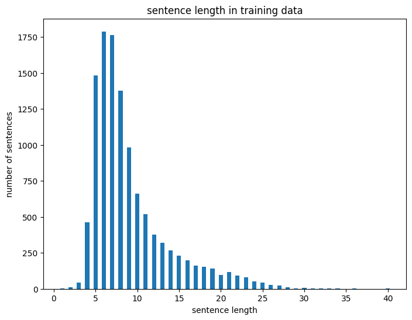

```python
from IPython.display import Image
Image(filename='image1.png')
```

Most of the data is concentrated at average length of 10 and maximum vector length can be treated as 35 with remaining ignored

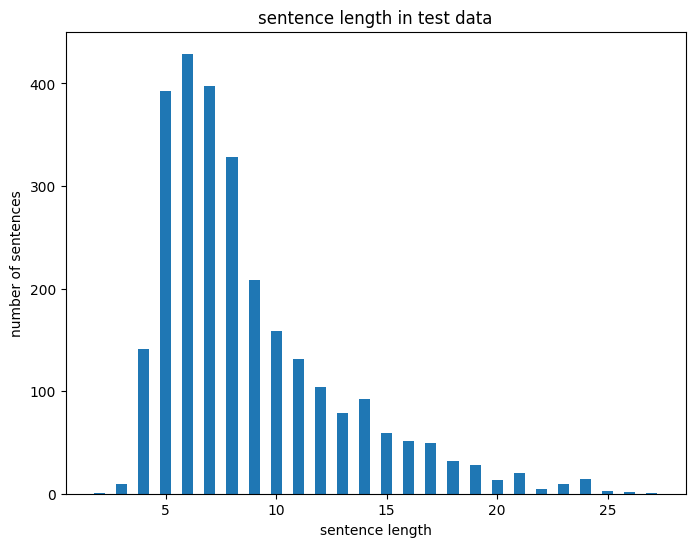

```python
from IPython.display import Image
Image(filename='image2.png')
```

Vector size of 30 or less than 30 should be good as test data maximum length of a sentence is less than 30

#### Vectorization

Applied doc2vec vectorization with following hyperparameters after performing hyper-parameter tuning:  
vector_size=25  
window=6  
min_count=1  
workers=1  
epochs=30  
alpha=0.1  
min_alpha=0.001  
hs=1

#### Recap of Approach1 as mentioned in project outline:

**Evaluation:**

Pearson Correlation values:

Training data : 0.53

Validation data : 0.59

Test data : 0.53

#### Residual analysis:

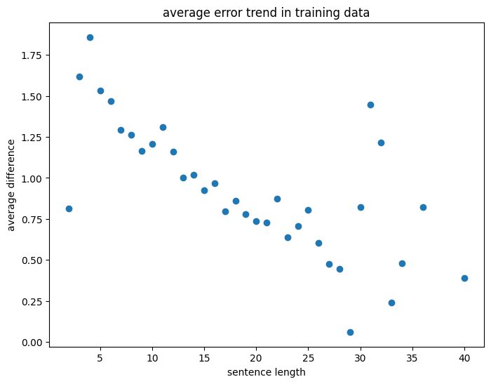

```python
Image(filename='image3.png')
```

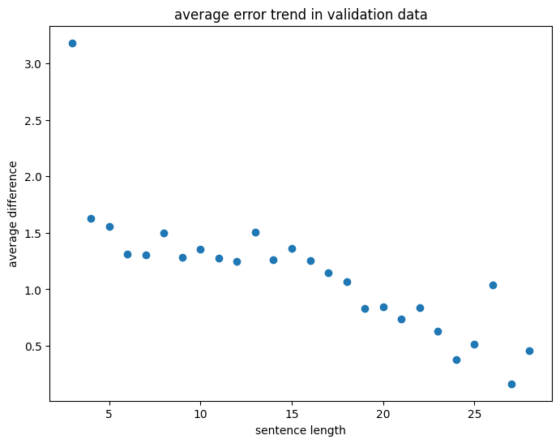

```python
Image(filename='image4.png')
```

### Next Steps:

#### Fine Tuning:

We will explore various text representation methods and apply model like SVM or Bidirectional LSTM model for better performance

#### Cross Lingual Semantics:

We will apply cross lingual semantic embeddings and generate similarity scores as a stretch goal of this project.

### Recap of project milestones:

We are precisely meeting the timelines as mentioned in the project outline.

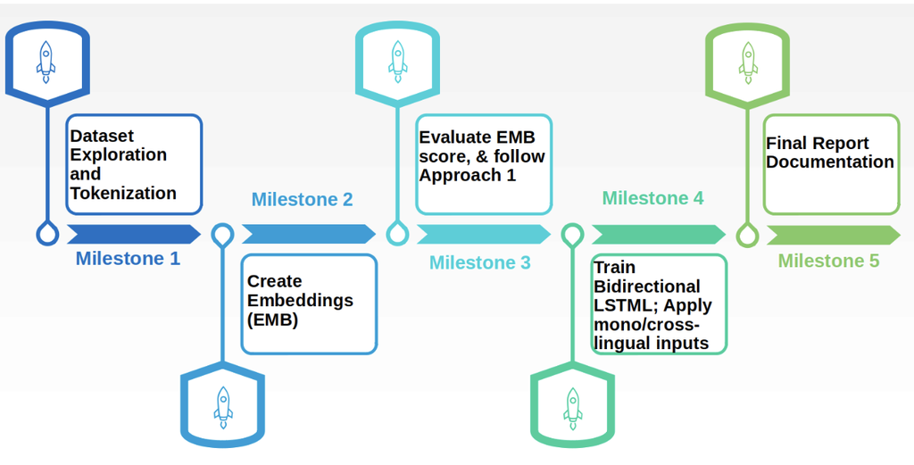

```python
Image(filename='image5.png')
```

### Code Artifacts:

The code developed so far is available in semantic_similiarity.ipynb file